# Shakespeare Visualisations

# Discussion Network

- All commenters on a discussion are considered to have interacted with one another (i.e. a complete graph is formed from the list of commenters on a discussion page)

For indicative purposes, a static visualisation of the total network is displayed below (force atlass 2 layout)

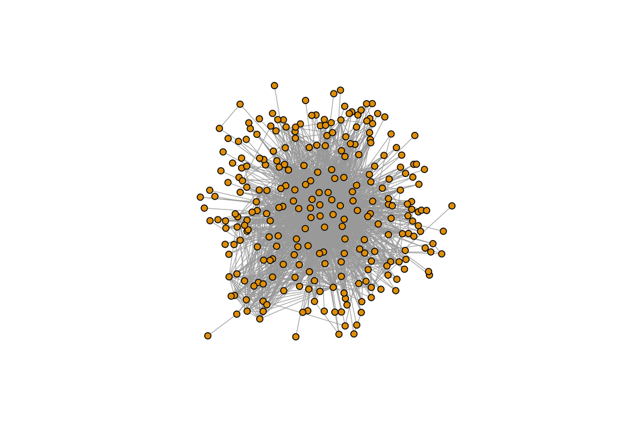

The distribution of data across the 9 boards is as follows:

|  | Board.Name | Discussions.in.Board | Commenters.in.Board | Edges.in.Board |
| --- | --- | --- | --- | --- |
| 1 | #Catholic | 7 | 11 | 14 |
| 2 | #OED | 21 | 20 | 90 |
| 3 | #Recipes2Try | 30 | 23 | 190 |
| 4 | FAQs | 15 | 33 | 184 |
| 5 | Help and Technical issues | 85 | 91 | 761 |
| 6 | News | 7 | 11 | 34 |
| 7 | Notes | 1065 | 211 | 4367 |
| 8 | Questions for the research team | 73 | 41 | 331 |
| 9 | Women writers and Autobiography | 2 | 7 | 16 |

The largest board is visualised as follows:

[interactive chart not shown]

# Frequency of Comments

The activity of users on the discussion boards is quite variable, with user “Cuboctahedron” racking up 1063 comments over all the boards and 37% of users only made one comment.

[interactive chart not shown]

In the network below, only those individuals in the #Notes board who have commented more than once across all boards are included:

[interactive chart not shown]

# Specific Boards

The sections below include visualisations/analyses of specific boards, note that these visualisations include ALL commenters unless otherwise specified

## OED Discussions

This is how commenters on the #OED board are connected to one another if multiple edges are allowed:

[interactive chart not shown]

Removing multiple edges:

[interactive chart not shown]

Include only those individuals who commented more than once:

[interactive chart not shown]

## Help & Technical Issues

[interactive chart not shown]

## Women

The “Women writers and autobiography” network appears as follows:

[interactive chart not shown]